# Кластерный анализ. Азия.

### Kmeans. 5 кластеров.

```r
set.seed(1234)
kmean5<-kmeans(df2[,2:6], 5, iter.max = 100,nstart = 50)
kmean5$centers
```

```
##           GDP    GDP.YoY Inflation.rate Jobless.rate    GDP/Pop
## 1 -0.27101209 -0.7081164     5.77902320   0.94259659 -0.5629963
## 2  0.04157882 -0.3217247    -0.36233508  -0.50836900  1.3843266
## 3 -0.18949660  0.2965019    -0.05489184  -0.02355421 -0.5079721
## 4 -0.29860314 -2.5499167     0.51789255   3.42786535 -0.6885226
## 5  6.20208826  0.7988111    -0.40280532  -0.45934989 -0.3090692
```

```r
for (i in 1:5){print(kmean5$cluster[kmean5$cluster==i])}
```

```
## Syria
##      1
##                Japan           South Korea                Taiwan
##                     2                     2                     2
## United Arab Emirates             Hong Kong                Israel
##                     2                     2                     2
##            Singapore                 Qatar                Kuwait
##                     2                     2                     2
##                 Oman                 Macau               Bahrain
##                     2                     2                     2
##               Brunei
##                     2
##        India     Indonesia  Saudi Arabia          Iran      Thailand
##             3             3             3             3             3
##     Malaysia   Philippines      Pakistan    Bangladesh       Vietnam
##             3             3             3             3             3
##   Kazakhstan          Iraq     Sri Lanka    Uzbekistan       Myanmar
##             3             3             3             3             3
##   Azerbaijan       Lebanon        Jordan  Turkmenistan         Nepal
##             3             3             3             3             3
##     Cambodia       Georgia      Mongolia          Laos       Armenia
##             3             3             3             3             3
##   Tajikistan    Kyrgyzstan     Palestine      Maldives        Bhutan
##             3             3             3             3             3
##   East Timor
##             3
##       Yemen  Afghanistan
##            4            4
## China
##      5
```

Kmeans выбрал один большой кластер со странанами, которые иерархическая кластеризация разбила на два, выделив страны с большим уровнем безработицы. При этом отдельно выделил Сирию и объединил Йемен и Афганистан, в то время как до этого Йемен и Сирия были в одном кластере, а Афганистан в кластере со странами с высоким уровнем безработицы.

```r
df4<-df1[,2:6]
row.names(df4)<-df[,1]
df4[c("Afghanistan","Syria","Yemen"),]
```

```
##              GDP GDP.YoY Inflation.rate Jobless.rate  GDP/Pop
## Afghanistan   19    0.02           0.07         0.40 0.701107
## Syria         74   -0.02           0.48         0.15 3.310962
## Yemen         37   -0.28           0.09         0.29 1.379053
```

```r
set.seed(1234)
kmean7<-kmeans(df2[,2:6], 7, iter.max = 100,nstart = 50)
kmean7$centers
```

```
##          GDP    GDP.YoY Inflation.rate Jobless.rate    GDP/Pop
## 1 -0.2932049 -5.0614625     0.64942081    2.7268921 -0.6697854
## 2 -0.3076002  0.4639383    -0.07398465    3.3004157 -0.6852979
## 3  6.2020883  0.7988111    -0.40280532   -0.4593499 -0.3090692
## 4  0.0678280 -0.1220890    -0.35896256   -0.5443163  1.4841572
## 5 -0.2719391 -0.2971362    -0.46259089    0.4327979 -0.4294437
## 6 -0.2710121 -0.7081164     5.77902320    0.9425966 -0.5629963
## 7 -0.1422639  0.4388229     0.17591906   -0.4019975 -0.5086780
```

```r
for (i in 1:7){print(kmean7$cluster[kmean7$cluster==i])}
```

```
## Yemen
##      1
## Afghanistan    Palestine
##            2            2
## China
##      3
##                Japan           South Korea                Taiwan
##                     4                     4                     4
## United Arab Emirates             Hong Kong                Israel
##                     4                     4                     4
##            Singapore                 Qatar                Kuwait
##                     4                     4                     4
##                Macau               Bahrain                Brunei
##                     4                     4                     4
##       Iran        Iraq        Oman     Lebanon      Jordan     Georgia
##           5           5           5           5           5           5
##   Mongolia     Armenia  Kyrgyzstan    Maldives  East Timor
##           5           5           5           5           5
## Syria
##      6
##        India     Indonesia  Saudi Arabia      Thailand      Malaysia
##             7             7             7             7             7
##  Philippines      Pakistan    Bangladesh       Vietnam    Kazakhstan
##             7             7             7             7             7
##    Sri Lanka    Uzbekistan       Myanmar    Azerbaijan  Turkmenistan
##             7             7             7             7             7
##        Nepal      Cambodia          Laos    Tajikistan        Bhutan
##             7             7             7             7             7
```

Получилось довольно хорошее разбиение на кластеры. Сразу стоит сказать, что порядок кластеров можем поменяться, но их состав должен остаться прежним.

Попробуем визуализировать полученные результаты на плоскости

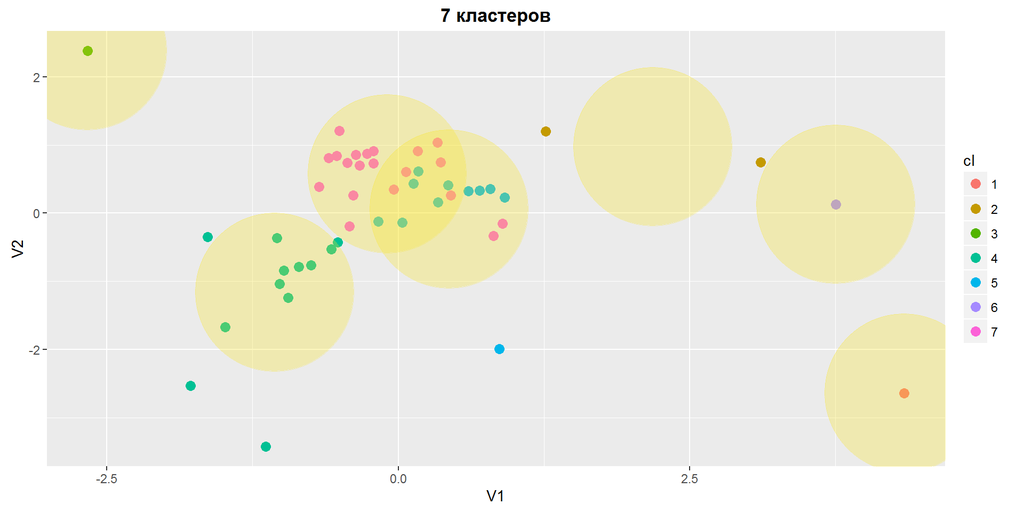

```r
df2.dist=dist(df2[,2:6])
df2.mds=cmdscale(df2.dist)
dfplot<-as.data.frame(df2.mds)
dfplot$cl<-as.factor(kmean7$cluster)
xc<-rep(0,7)
for (i in 1:7){
  xc[i]<-sum(dfplot[which(dfplot[,3]==i),1])/length(dfplot[which(dfplot[,3]==i),1])
}
yc<-rep(0,7)
for (i in 1:7){
  yc[i]<-sum(dfplot[which(dfplot[,3]==i),2])/length(dfplot[which(dfplot[,3]==i),2])
}
centers<-data.frame(xc=xc,yc=yc)
ggplot(dfplot,aes(x=V1,y=V2))+geom_point(aes(col=cl),size=3)+geom_point(data=centers,aes(x=xc,y=yc),col="#f9e526", size=52, alpha=.3)+
  ggtitle("7 кластеров")+theme(plot.title = element_text(lineheight=1, face="bold"))
```

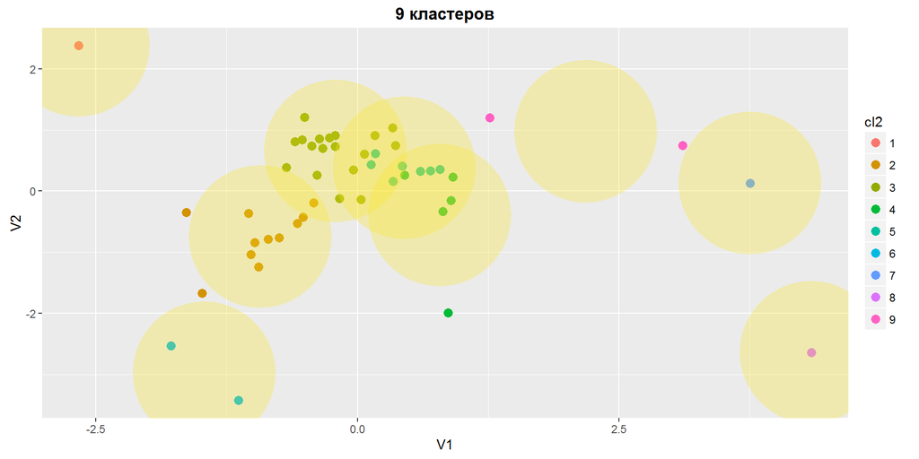

```r
dfplot$cl2<-as.factor(groupsW9)
xc2<-rep(0,9)
for (i in 1:9){
  xc2[i]<-sum(dfplot[which(dfplot[,4]==i),1])/length(dfplot[which(dfplot[,4]==i),1])
}
yc2<-rep(0,9)
for (i in 1:9){
  yc2[i]<-sum(dfplot[which(dfplot[,4]==i),2])/length(dfplot[which(dfplot[,4]==i),2])
}
centers2<-data.frame(xc=xc2,yc=yc2)
ggplot(dfplot,aes(x=V1,y=V2))+geom_point(aes(col=cl2),size=3)+geom_point(data=centers2,aes(x=xc,y=yc),col="#f9e526", size=52, alpha=.3)+
  ggtitle("9 кластеров")+theme(plot.title = element_text(lineheight=1, face="bold"))
```

На основе этих графиков можно сделать лишь поверхностные выводы, так как довольно большая часть информации потеряна в связи с переходом к двум осям. Например, если бы пытались сократить размерность методом главных компонент, то сохранили бы чуть более половины всей информации.

```r
dfpca<-prcomp(df2[,2:6])
summary(dfpca)
```

```
## Importance of components:
##                           PC1    PC2    PC3    PC4     PC5
## Standard deviation     1.2566 1.0921 0.9534 0.9364 0.66517
## Proportion of Variance 0.3158 0.2386 0.1818 0.1754 0.08849
## Cumulative Proportion  0.3158 0.5543 0.7361 0.9115 1.00000
```

Однако, определенное представление о данных получить можно. В частности хорошо заметны сильно выделяющиеся страны.

### Вывод

Методы иерархической кластеризации показали себя довольно неплохо и дали схожие результаты. Число выделяемых кластеров может варьироваться в зависимости от того, насколько детальный анализ необходим. Для более точной кластеризации также можно попробовать взять больше экономических показателей или попробовать другие методы кластеризации.На мой взгляд 7 кластеров, полученные в результате использования kmeans, являются в нашем случае золотой серединой между 5 и 9 кластерами и поддаются неплохой интерпретации. Стоит также заметить, что каменистая осыпь для kmeans давала разные результаты в зависимости от начального выбора центроидов. Так, на различных графиках можно было выделить 4,5,6,7 и 9 кластеров. Поэтому при выборе числа кластеров имеет смысл также ориентироваться на иерархическую кластеризацию, так как она показала неплохие результаты.